# Window-Size Sensitivity of Genome-Wide Tm Profiles

Junhui Li, Lihua Julie Zhu

2026-10-20

# 1 Introduction

Any window-based genomic profile depends on the window size, which acts as a smoothing bandwidth: too large and local signal is averaged away, too small and single-window noise dominates. This vignette quantifies that dependence for **TmCalculator** by recomputing the *Escherichia coli* K-12 MG1655 Tm/GC profile at 50, 100, 200 and 500 bp and asking two separate questions.

1. Does window size change the thermodynamic landscape itself?
2. Does it change a biological conclusion drawn from that landscape?

The companion vignette `vignette("genome_wide_tm_ecoli", package = "TmCalculator")` develops the full case study at the 200 bp resolution used by Hasenauer *et al.* (2025), including the MutL-associated region (MutL-AR) comparison that is re-tested here at every window size.

# 2 Setup

We reproduce the minimum needed from the main case study: the genome, the MutL-AR peak coordinates, and the reference labels used for plotting.

```r
library(TmCalculator)
library(GenomicRanges)
library(IRanges)
library(GenomeInfoDb)
```

The *E. coli* genome is supplied by the pre-forged `BSgenome.Ecoli.NCBI.ASM584v2` package. The chunk below installs it if it is not already available, exactly as in the main case-study vignette; see that vignette for how the package is forged from the NCBI assembly accession.

```r
ecoli_pkg  <- "BSgenome.Ecoli.NCBI.ASM584v2"
genome_obj <- "Ecoli"   # BSgenomeObjname in DESCRIPTION; not the package name

.ecoli_genome_ready <- function() {
  if (!requireNamespace(ecoli_pkg, quietly = TRUE)) return(FALSE)
  exists(genome_obj, envir = asNamespace(ecoli_pkg), inherits = FALSE)
}

if (!.ecoli_genome_ready()) {
  if (!requireNamespace("remotes", quietly = TRUE)) {
    utils::install.packages("remotes", repos = "https://cloud.r-project.org")
  }
  remotes::install_github(
    "JunhuiLi1017/BSgenome.Ecoli.NCBI.ASM584v2",
    upgrade = "never",
    quiet = TRUE
  )
}

if (!.ecoli_genome_ready()) {
  stop(
    "Could not load genome object '", genome_obj, "' from package '",
    ecoli_pkg, "'.\n",
    "See vignette(\"genome_wide_tm_ecoli\") for how to forge it locally.",
    call. = FALSE
  )
}
```

```r
suppressPackageStartupMessages(library(ecoli_pkg, character.only = TRUE))
genome      <- base::get(genome_obj, envir = asNamespace(ecoli_pkg))
genome_name <- ecoli_pkg
chr_name    <- "U00096.3"
chr_length  <- GenomeInfoDb::seqlengths(genome)[[chr_name]]

data(ecoli_rep_hotspots)

## MutL-AR peaks, as in the main case study
mutH_peaks <- GRanges(
  seqnames = ecoli_rep_hotspots$all_peaks_IP_mutH$chr,
  ranges   = IRanges(start = ecoli_rep_hotspots$all_peaks_IP_mutH$start,
                     end   = ecoli_rep_hotspots$all_peaks_IP_mutH$end)
)
seqlevels(mutH_peaks) <- chr_name
mutH_peaks$peak_id <- paste0("mutH_", seq_along(mutH_peaks))

## Reference labels: replication origin (ori) and terminus (dif)
label <- data.frame(
  seqnames = genome_name,
  start    = c(3925804, 1590777),
  end      = c(3925804, 1590777),
  label    = c("ori", "dif")
)
```

# 3 Sensitivity analysis

For each window size we retile the chromosome, recompute Tm and GC, and re-run the MutL-AR comparison, keeping every other setting fixed. Nothing downstream needs to change: the annotation layers keep their own native resolutions (1 kb bins for the microsatellite, cruciform and GATC density tracks; variable-width intervals for MutL-AR peaks and ssDNA regions), and both `plot_genome_track()` and the overlap-based statistics work across mixed resolutions.

```r
window_sizes <- c(50L, 100L, 200L, 500L)

sens <- lapply(window_sizes, function(w) {
  bins_w <- make_genomiccoord(
    bsgenome = genome_name, chromosomes = chr_name,
    window = w, slide = w, start = 1, end = chr_length,
    strand = "+", verbose = FALSE
  )
  gr_w <- to_genomic_ranges_fast(list(pkg_name = genome_name, seq = bins_w))
  tm_w <- tm_calculate(gr_w, method = "tm_nn",
                       nn_table = "DNA_NN_Breslauer_1986", Na = 50)$gr

  ann <- integrate_granges(gr_tm = tm_w, gr_features = mutH_peaks,
                           strategy = "overlap", feature_cols = "peak_id",
                           keep_unmatched = TRUE)
  ann$in_mutH <- ifelse(is.na(ann$peak_id), "non_peak", "peak")
  cg <- compare_groups(gr = ann, target = c("Tm", "GC"),
                       method = "wilcoxon", group = "in_mutH",
                       alternative = "greater", posthoc = FALSE)
  list(gr = tm_w, ann = ann, test = cg)
})
names(sens) <- paste0("w", window_sizes)
```

## 3.1 Distributional stability

```r
dist_tbl <- do.call(rbind, lapply(seq_along(window_sizes), function(i) {
  g <- sens[[i]]$gr
  data.frame(
    window_bp = window_sizes[i],
    n_windows = length(g),
    Tm_mean   = mean(g$Tm, na.rm = TRUE),
    Tm_sd     = stats::sd(g$Tm, na.rm = TRUE),
    Tm_IQR    = stats::IQR(g$Tm, na.rm = TRUE),
    GC_mean   = mean(g$GC, na.rm = TRUE)
  )
}))
knitr::kable(dist_tbl, digits = 3,
             caption = "Tm/GC distribution by window size.")
```

Tm/GC distribution by window size.

| window_bp | n_windows | Tm_mean | Tm_sd | Tm_IQR | GC_mean |
| --- | --- | --- | --- | --- | --- |
| 50 | 92833 | 84.175 | 5.293 | 6.796 | 50.791 |
| 100 | 46416 | 93.973 | 4.380 | 5.275 | 50.791 |
| 200 | 23208 | 98.984 | 3.804 | 4.405 | 50.791 |
| 500 | 9283 | 102.028 | 3.245 | 3.635 | 50.791 |

The same two effects are easier to read as distributions than as summary statistics: the curve moves to the right as the window lengthens, and it narrows at the same time.

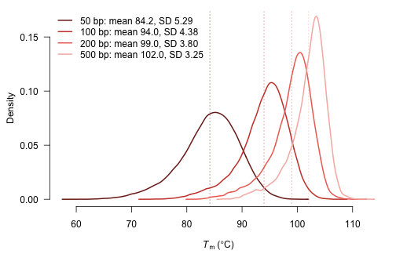

Tm distribution at each window size. The distribution shifts to higher Tm as the window lengthens and narrows at the same time; dotted vertical lines mark the group means. Colours match the multi-scale tracks below (darkest = 50 bp, lightest = 500 bp).

```r
## Palettes are defined here because they are used both by this panel and by
## the multi-scale track figures further down.
## darkest = finest window (50 bp), lightest = coarsest (500 bp)
scale_cols_gc <- c("#1A5276", "#2E86C1", "#5DADE2", "#AED6F1")
scale_cols_tm <- c("#7B241C", "#CB4335", "#EC7063", "#F5B7B1")

## Densities are normalised, so the ~93,000 windows at 50 bp and the ~9,300
## at 500 bp can be compared directly on one pair of axes.
tm_by_size <- lapply(sens, function(x) x$gr$Tm[is.finite(x$gr$Tm)])
dens <- lapply(tm_by_size, stats::density)

xlim <- range(vapply(dens, function(z) range(z$x), numeric(2)))
ylim <- c(0, max(vapply(dens, function(z) max(z$y), numeric(1))))

op <- par(mar = c(4.2, 4.4, 0.8, 0.8), las = 1)
plot(NA, xlim = xlim, ylim = ylim, bty = "n",
     xlab = expression(italic(T)[m] ~ "(" * degree * "C)"),
     ylab = "Density")
for (i in seq_along(dens)) {
  lines(dens[[i]], col = scale_cols_tm[i], lwd = 2)
  abline(v = dist_tbl$Tm_mean[i], col = scale_cols_tm[i], lwd = 1, lty = 3)
}
legend("topleft", bty = "n", lwd = 2, seg.len = 1.6,
       col = scale_cols_tm[seq_along(window_sizes)],
       legend = sprintf("%d bp: mean %.1f, SD %.2f",
                        dist_tbl$window_bp, dist_tbl$Tm_mean, dist_tbl$Tm_sd))
```

```r
par(op)

## Spread of the finest window relative to the coarsest. This is the ratio
## quoted in the manuscript, so both come from the same computation.
sd_ratio <- dist_tbl$Tm_sd[1] / dist_tbl$Tm_sd[nrow(dist_tbl)]
```

Two systematic effects are visible, both expected. First, mean Tm rises with window length (84.2 to 102.0 degrees C from 50 to 500 bp): duplex stability increases with length in the nearest-neighbor model, so absolute Tm values are only comparable *within* one window size. Second, shorter windows widen the distribution (SD 5.29 at 50 bp vs 3.25 at 500 bp, a ratio of 1.63) – window size acts as a smoothing bandwidth. The mean GC is invariant (50.791 throughout), confirming that the composition landscape itself does not depend on the tiling.

## 3.2 Cross-scale agreement

Every profile is aggregated onto one common grid (mean Tm per bin) and the resulting series are correlated.

The grid is 1 kb rather than 500 bp, and the choice matters. Correlating against the 500 bp profile directly makes 200 bp the odd one out: 50 and 100 divide 500 exactly, into ten and five windows per bin, but 200 does not, so each bin receives two or three windows that straddle its boundaries and the aggregation is itself inexact. That alone drove the 200 bp correlation down to 0.976 while the two finer profiles reached 0.997 and 0.999, an ordering that would invite the reader to conclude that the closest resolution agrees worst. All four window sizes divide 1 kb (into 20, 10, 5 and 2), so on that grid every profile is aggregated exactly and the comparison is between profiles rather than between remainders. The 500 bp profile is aggregated too, and serves as the reference.

```r
grid_bp <- 1000L
stopifnot(all(grid_bp %% window_sizes == 0L))   # exact aggregation for each

gr_ref  <- sens[["w500"]]$gr
ref_agg <- tapply(gr_ref$Tm, (start(gr_ref) - 1L) %/% grid_bp,
                  mean, na.rm = TRUE)

cor_tbl <- vapply(c("w50", "w100", "w200"), function(k) {
  g      <- sens[[k]]$gr
  agg    <- tapply(g$Tm, (start(g) - 1L) %/% grid_bp, mean, na.rm = TRUE)
  common <- intersect(names(agg), names(ref_agg))
  stats::cor(agg[common], ref_agg[common], use = "complete.obs")
}, numeric(1))
round(cor_tbl, 3)
```

```
##   w50  w100  w200
## 0.998 0.999 1.000
```

Aggregated onto the common 1 kb grid, the profiles are nearly interchangeable (r = 0.998, 0.999, 1.000 for 50, 100 and 200 bp respectively). Agreement now rises monotonically as the window approaches the grid, which is what averaging fewer windows per bin should do, and is the behaviour the 500 bp grid obscured. Window size rescales and smooths the profile but preserves the spatial landscape.

## 3.3 Robustness of the MutL-AR association

Finally, the vignette’s biological conclusion – that Tm and GC differ between MutL-AR peak windows and the genomic background – is re-tested at every window size:

```r
## Per-window-size test statistics
test_results <- do.call(rbind, lapply(seq_along(window_sizes), function(i) {
  data.frame(window_bp = window_sizes[i], sens[[i]]$test$results)
}))
test_results
```

```
##   window_bp target   group   method              test statistic df      p.value
## 1        50     Tm in_mutH wilcoxon Wilcoxon rank-sum 168689038 NA 5.332133e-90
## 2        50     GC in_mutH wilcoxon Wilcoxon rank-sum 160420084 NA 7.452204e-48
## 3       100     Tm in_mutH wilcoxon Wilcoxon rank-sum  44137500 NA 1.210830e-65
## 4       100     GC in_mutH wilcoxon Wilcoxon rank-sum  41400570 NA 1.192782e-32
## 5       200     Tm in_mutH wilcoxon Wilcoxon rank-sum  11638890 NA 1.165544e-44
## 6       200     GC in_mutH wilcoxon Wilcoxon rank-sum  10806568 NA 8.549859e-22
## 7       500     Tm in_mutH wilcoxon Wilcoxon rank-sum   2032348 NA 6.058121e-25
## 8       500     GC in_mutH wilcoxon Wilcoxon rank-sum   1873428 NA 1.417503e-12
##   n_groups n_total    group_levels                   group_n
## 1        2   92833 non_peak | peak non_peak=89730, peak=3103
## 2        2   92833 non_peak | peak non_peak=89730, peak=3103
## 3        2   46416 non_peak | peak non_peak=44845, peak=1571
## 4        2   46416 non_peak | peak non_peak=44845, peak=1571
## 5        2   23208 non_peak | peak  non_peak=22402, peak=806
## 6        2   23208 non_peak | peak  non_peak=22402, peak=806
## 7        2    9283 non_peak | peak   non_peak=8940, peak=343
## 8        2    9283 non_peak | peak   non_peak=8940, peak=343
```

```r
## Per-window-size group summaries, plus the median Tm effect size
test_summary <- do.call(rbind, lapply(seq_along(window_sizes), function(i) {
  ann <- sens[[i]]$ann
  med <- tapply(ann$Tm, ann$in_mutH, stats::median, na.rm = TRUE)
  data.frame(window_bp   = window_sizes[i],
             n_peak      = sum(ann$in_mutH == "peak"),
             Tm_med_diff = unname(med["peak"] - med["non_peak"]),
             sens[[i]]$test$summary)
}))
test_summary
```

```
##    window_bp n_peak Tm_med_diff    group     n      mean       sd    median
## 1         50   3103   -1.990208 non_peak 89730  84.24287 5.268938  84.69220
## 2         50   3103   -1.990208     peak  3103  82.20245 5.604584  82.70199
## 3         50   3103   -1.990208 non_peak 89730  50.87955 8.832840  52.00000
## 4         50   3103   -1.990208     peak  3103  48.22172 9.789787  50.00000
## 5        100   1571   -1.679963 non_peak 44845  94.04177 4.351182  94.64914
## 6        100   1571   -1.679963     peak  1571  92.01899 4.741047  92.96917
## 7        100   1571   -1.679963 non_peak 44845  50.88135 7.326739  52.00000
## 8        100   1571   -1.679963     peak  1571  48.21260 8.384205  50.00000
## 9        200    806   -1.770487 non_peak 22402  99.05293 3.771603  99.72991
## 10       200    806   -1.770487     peak   806  97.05677 4.190587  97.95942
## 11       200    806   -1.770487 non_peak 22402  50.88340 6.346952  52.00000
## 12       200    806   -1.770487     peak   806  48.22333 7.394710  50.00000
## 13       500    343   -1.688334 non_peak  8940 102.09817 3.207335 102.74918
## 14       500    343   -1.688334     peak   343 100.19893 3.674088 101.06084
```

[output cut: 19 more lines]

## 3.4 One table for the whole analysis

Both questions are answered by the same four rows, so they are assembled into a single table: the first four columns say what window size does to the landscape, and the last three say what it does to the conclusion drawn from it.

```r
sens_tbl <- do.call(rbind, lapply(seq_along(window_sizes), function(i) {
  g   <- sens[[i]]$gr
  ann <- sens[[i]]$ann
  med <- tapply(ann$Tm, ann$in_mutH, stats::median, na.rm = TRUE)
  res <- sens[[i]]$test$results
  w   <- window_sizes[i]
  data.frame(
    `Window (bp)`        = w,
    Windows              = length(g),
    `Tm mean (C)`        = mean(g$Tm, na.rm = TRUE),
    `Tm SD`              = stats::sd(g$Tm, na.rm = TRUE),
    `GC mean (%)`        = mean(g$GC, na.rm = TRUE),
    ## The reference profile correlates with itself by construction.
    `r vs 1 kb grid`     = if (w == max(window_sizes)) NA_real_
                           else unname(cor_tbl[[paste0("w", w)]]),
    `MutL-AR windows`    = sum(ann$in_mutH == "peak"),
    `Tm peak - bg (C)`   = unname(med["peak"] - med["non_peak"]),
    ## Formatted as character: these p values span sixty-five orders of
    ## magnitude, and rounding them to a fixed number of decimals prints
    ## every one of them as zero.
    `p (Tm)`             = format(res$p.value[res$target == "Tm"],
                                  digits = 2, scientific = TRUE),
    check.names = FALSE, stringsAsFactors = FALSE)
}))
knitr::kable(sens_tbl, digits = c(0, 0, 2, 2, 2, 3, 0, 3, 0),
             caption = paste("Window-size sensitivity. GC mean is invariant;",
                             "the Tm distribution shifts and narrows; the",
                             "MutL-AR effect size varies within a few tenths",
                             "of a degree while the p value tracks the number",
                             "of windows."))
```

Window-size sensitivity. GC mean is invariant; the Tm distribution shifts and narrows; the MutL-AR effect size varies within a few tenths of a degree while the p value tracks the number of windows.

| Window (bp) | Windows | Tm mean (C) | Tm SD | GC mean (%) | r vs 1 kb grid | MutL-AR windows | Tm peak - bg (C) | p (Tm) |
| --- | --- | --- | --- | --- | --- | --- | --- | --- |
| 50 | 92833 | 84.17 | 5.29 | 50.79 | 0.998 | 3103 | -1.990 | 5.3e-90 |
| 100 | 46416 | 93.97 | 4.38 | 50.79 | 0.999 | 1571 | -1.680 | 1.2e-65 |
| 200 | 23208 | 98.98 | 3.80 | 50.79 | 1.000 | 806 | -1.770 | 1.2e-44 |
| 500 | 9283 | 102.03 | 3.25 | 50.79 | NA | 343 | -1.688 | 6.1e-25 |

The last two columns are the point of the section. The p value falls by sixty-five orders of magnitude between the coarsest and the finest tiling, which is a statement about how many windows were tested rather than about how far apart the two groups are. The difference in medians, which is that statement, stays between -1.7 and -2.0 degrees C. The finest tiling gives the largest separation, as expected: a 500 bp window overlapping a MutL-AR peak also contains flanking sequence that does not, and averaging over it dilutes the contrast, whereas a 50 bp window resolves the peak more sharply. The three coarser tilings agree within 0.1 degrees C.

## 3.5 Multi-scale tracks alongside the multi-omics layers

Because every track keeps its native resolution, the four Tm/GC profiles can be drawn as concentric layers of one integrated figure, together with the annotation data:

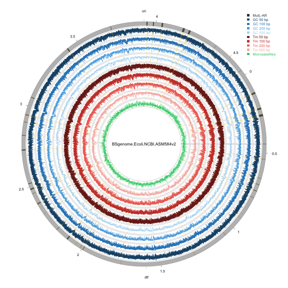

Multi-scale integration. Concentric rings from outside in: MutL-AR peaks (ideogram), GC content at 50/100/200/500 bp (blues), Tm at 50/100/200/500 bp (reds), and microsatellite density (green). Yellow bands mark MutL-AR peaks.

```r
## scale_cols_gc / scale_cols_tm are defined in the density-panel chunk above
sens_dfs <- lapply(sens, function(x) as.data.frame(x$gr[, c("Tm", "GC")]))

tracks_scale <- c(
  list(list(type = "rect", data = ecoli_rep_hotspots$all_peaks_IP_mutH,
            col = "#2C3E50", bg.col = "grey", name = "MutL-AR",
            legend_font_col = "#2C3E50", ideogram = TRUE, height = 0.5)),
  lapply(seq_along(window_sizes), function(i)
    list(type = "line", data = sens_dfs[[i]], value_col = "GC",
         name = paste0("GC ", window_sizes[i], " bp"),
         col = scale_cols_gc[i], legend_font_col = scale_cols_gc[i])),
  lapply(seq_along(window_sizes), function(i)
    list(type = "line", data = sens_dfs[[i]], value_col = "Tm",
         name = paste0("Tm ", window_sizes[i], " bp"),
         col = scale_cols_tm[i], legend_font_col = scale_cols_tm[i])),
  list(list(type = "line", data = ecoli_rep_hotspots$bins_rep,
            value_col = "count", name = "Microsatellites", col = "#2ECC71",
            legend_font_col = "#2ECC71"),
       list(type = "highlight",
            data = ecoli_rep_hotspots$all_peaks_IP_mutH,
            col = "#F1C40F", alpha = 0.18))
)

plot_genome_track(
  genome_name = genome_name,
  genome_size = chr_length,
  track_list  = tracks_scale,
  circular    = TRUE,
  label       = label
)
```

At whole-genome scale the four bandwidths look nearly identical – the landscape is invariant. The difference window size makes is local smoothing, best seen in a zoomed view of the same interval used by the main case study:

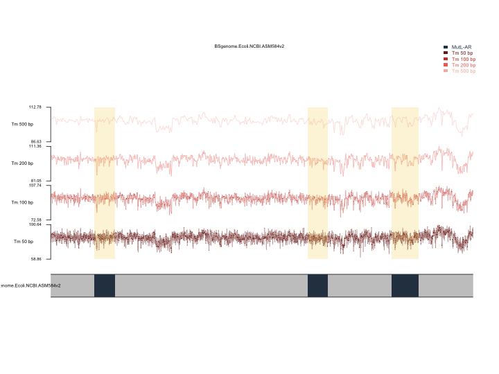

The 0.1-0.3 Mb region, within the interval shown in the genome-wide figure of the main case study, with Tm computed at 50, 100, 200 and 500 bp (dark to light). The 50 bp profile resolves single-window fluctuations that the 500 bp profile averages away, but all four trace the same underlying landscape. Yellow bands mark MutL-AR peaks.

```r
## Only the four Tm profiles are drawn. Ten line tracks in one linear panel
## leave each too little vertical space for its own axis labels, which then
## collide, and everything except Tm is answering a different question: the
## GC layers duplicate what the summary table already gives numerically, and
## the microsatellite density is the subject of the main case study's figure,
## not of this one. Removing both leaves five tracks with room to be read.
## The full ten-track version is the circular figure above.
##
## The interval is the one used in the main case study's zoomed panel, so the
## two figures can be read against each other rather than against different
## parts of the chromosome.
tracks_zoom <- c(
  list(list(type = "rect", data = ecoli_rep_hotspots$all_peaks_IP_mutH,
            col = "#2C3E50", bg.col = "grey", name = "MutL-AR",
            legend_font_col = "#2C3E50", ideogram = TRUE, height = 0.6)),
  lapply(seq_along(window_sizes), function(i)
    list(type = "line", data = sens_dfs[[i]], value_col = "Tm",
         name = paste0("Tm ", window_sizes[i], " bp"),
         col = scale_cols_tm[i], legend_font_col = scale_cols_tm[i],
         height = 1.2)),
  list(list(type = "highlight",
            data = ecoli_rep_hotspots$all_peaks_IP_mutH,
            col = "#F1C40F", alpha = 0.18))
)

plot_genome_track(
  genome_name = genome_name,
  genome_size = chr_length,
  track_list  = tracks_zoom,
  zoom        = "U00096.3:100000-300000",
  track.gap   = 0.03,
  axis.cex    = 0.55
)
```